# Hayman Fire Recovery

Megan Sears

2022-02-02

```r
library(tidyverse)
library(tidyr)
library(ggthemes)
library(lubridate)
library(ggrepel)

# Now that we have learned how to munge (manipulate) data
# and plot it, we will work on using these skills in new ways

knitr::opts_knit$set(root.dir='..')
```

```r
####-----Reading in Data and Stacking it ----- ####
#Reading in files
files <- list.files('data',full.names=T)


#Read in individual data files
ndmi <- read_csv(files[1]) %>%
  rename(burned=2,unburned=3) %>%
  mutate(data='ndmi')


ndsi <- read_csv(files[2]) %>%
  rename(burned=2,unburned=3) %>%
  mutate(data='ndsi')

ndvi <- read_csv(files[3])%>%
  rename(burned=2,unburned=3) %>%
  mutate(data='ndvi')

# Stack as a tidy dataset
full_long <- rbind(ndvi,ndmi,ndsi) %>%
  gather(key='site',value='value',-DateTime,-data) %>%
  filter(!is.na(value))
```

## Question 1)

What is the correlation between NDVI and NDMI? - here I want you to convert the full_long dataset in to a wide dataset using the function “spread” and then make a plot that shows the correlation as a function of if the site was burned or not (x axis should be ndmi) You should exclude winter months and focus on summer months

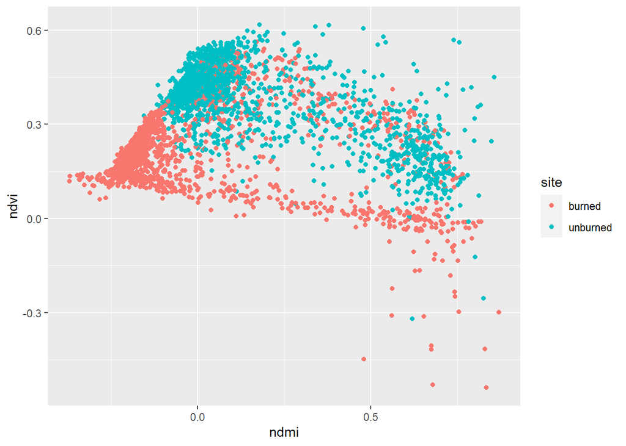

```r
#make wide data format
full_wide <- spread(data=full_long,key='data',value='value') %>%
  filter_if(is.numeric,all_vars(!is.na(.))) %>%
  mutate(month = month(DateTime),
         year = year(DateTime))


full_summer <- full_wide %>%
  filter_if(is.numeric,all_vars(!is.na(.)))


ggplot(full_summer, aes(ndmi, ndvi, color=site)) +
  geom_point()
```

## Question 2

2. What is the correlation between average NDSI (normalized snow index) for January - April and average NDVI for June-August? In other words, does the previous year’s snow cover influence vegetation growth for the following summer?

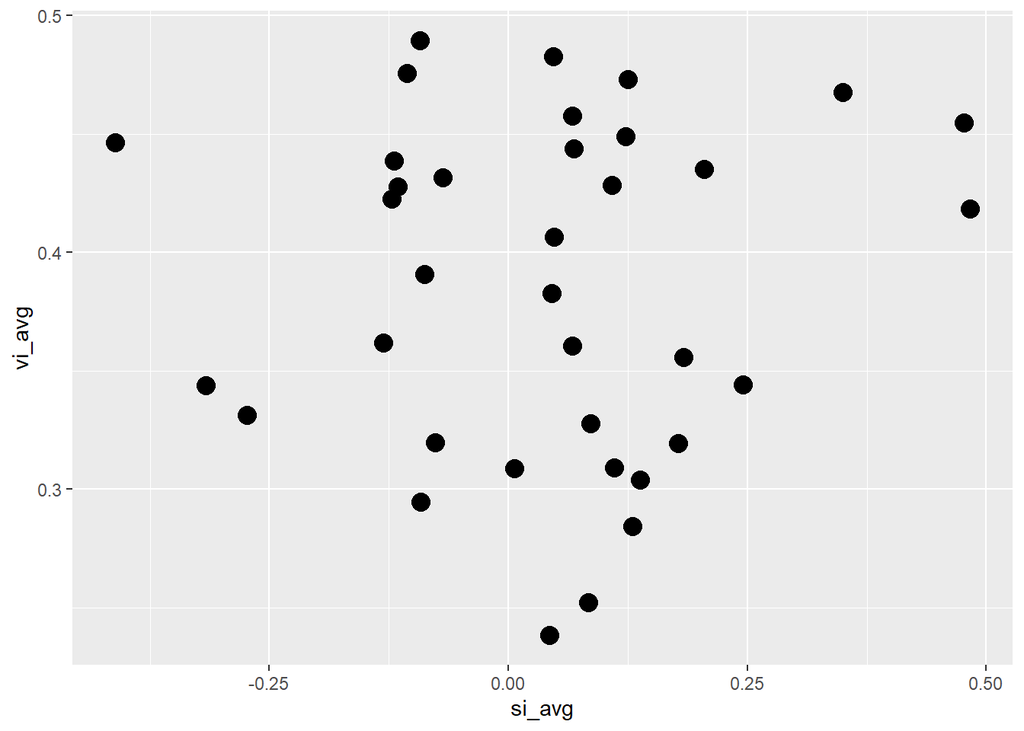

```r
#ndsi for burned and unburned combined
ndsi_win <- full_wide %>%
  filter(month %in% c(1,2,3,4)) %>%
  group_by(year) %>%
  summarize(si_avg = mean(ndsi))

#ndvi for burned and unburned combined
ndvi_summ <- full_wide %>%
  filter(month %in% c(6,7,8)) %>%
  group_by(year) %>%
  summarize(vi_avg = mean(ndvi))

#join the 2 above
q2_pt1 <- inner_join(ndsi_win, ndvi_summ, by=c("year"))

#plot showing comparison of ndsi and ndvi for burn and unburn combined
ggplot(q2_pt1, aes(x=si_avg, y=vi_avg)) +
  geom_point(size=4)
```

```r
#ndsi grouped by year and site
ndsi_q2 <- full_wide %>%
    filter(month %in% c(1,2,3,4)) %>%
  group_by(year, site) %>%
  summarize(si_avg = mean(ndsi))
#ndvi grouped by year and site
ndvi_q2 <- full_wide %>%
  filter(month %in% c(6,7,8)) %>%
  group_by(year, site) %>%
  summarize(vi_avg = mean(ndvi))
```

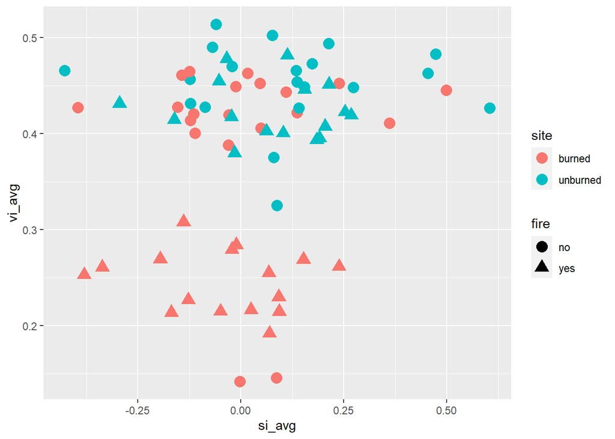

```r
#ndvi and ndsi comparison by year and site for pre and post burn
#this answers q3
q2 <- inner_join(ndsi_q2, ndvi_q2, by=c("year", "site")) %>%
  mutate(fire = if_else(year > 2003, "yes", "no"))

ggplot(q2, aes(x=si_avg, y=vi_avg, color=site, shape=fire)) +
  geom_point(size=4)
```

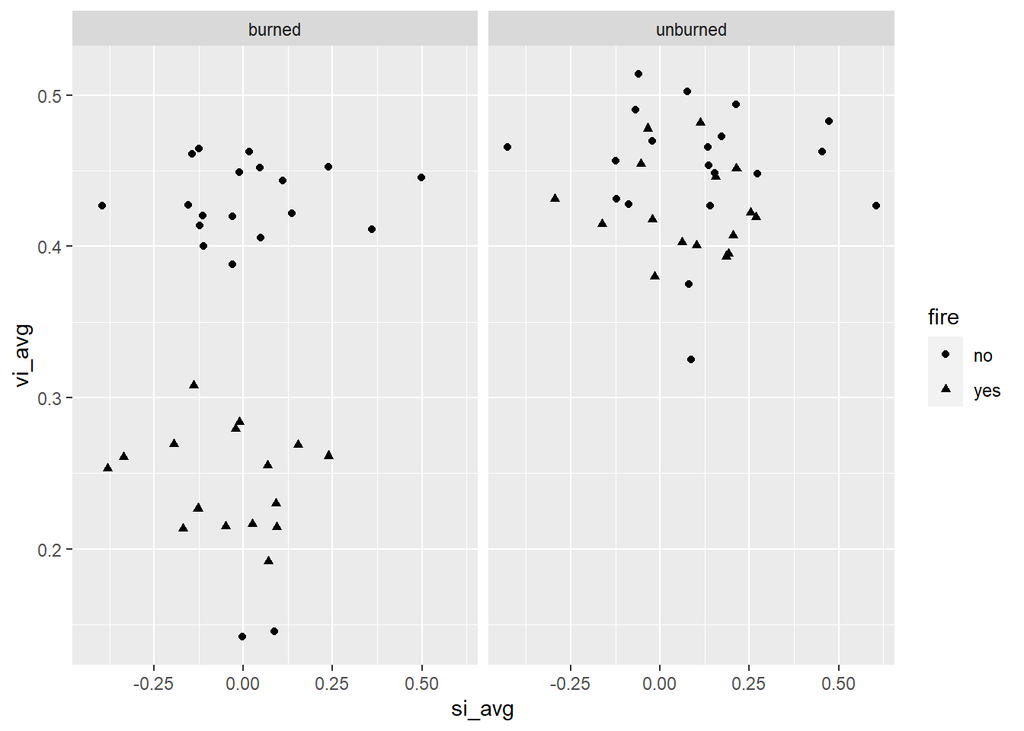

```r
#adding facet wrap to break out the burn and unburned - this answers q3
ggplot(q2, aes(x=si_avg, y=vi_avg, shape=fire)) +
  geom_point() +
  facet_wrap(~site)
```

## Q3

How is the snow effect from question 2 different between pre- and post-burn and burned and unburned?

Answers included in the q2 chunk.

## Question 4

What month is the greenest month on average?

```r
#greenest month
mean_summary <- full_wide %>%
  group_by(month) %>%
  summarize(moavg_ndvi = mean(ndvi),
            moavg_ndsi = mean(ndsi),
            moavg_ndmi = mean(ndmi))

mean_summary
```

```
## # A tibble: 12 x 4
##    month moavg_ndvi moavg_ndsi moavg_ndmi
##  * <dbl>      <dbl>      <dbl>      <dbl>
##  1     1      0.219     0.210     0.422
##  2     2      0.199     0.198     0.401
##  3     3      0.201    -0.0435    0.200
##  4     4      0.250    -0.231     0.0728
##  5     5      0.305    -0.412    -0.0549
##  6     6      0.351    -0.442    -0.0452
##  7     7      0.364    -0.451    -0.0442
##  8     8      0.387    -0.459    -0.0320
##  9     9      0.383    -0.455    -0.0251
## 10    10      0.357    -0.41      0.00541
## 11    11      0.285    -0.115     0.203
## 12    12      0.251     0.124     0.377
```

## Bonus Question: Redo all problems with `spread` and `gather` using modern tidyverse syntax.

```r
####-----Reading in Data and Stacking it ----- ####
#Reading in files
#files <- list.files('../data',full.names=T)


#Read in individual data files
#ndmi <- read_csv(files[1]) %>%
#  rename(burned=2,unburned=3) %>%
#  mutate(data='ndmi')

#ndsi <- read_csv(files[2]) %>%
#  rename(burned=2,unburned=3) %>%
#  mutate(data='ndsi')

#ndvi <- read_csv(files[3])%>%
#  rename(burned=2,unburned=3) %>%
#  mutate(data='ndvi')

# Stack as a tidy dataset
#full_long <- rbind(ndvi,ndmi,ndsi) %>%
#  pivot_longer(!c(DateTime, data), names_to="condition", values_to="value" ) %>%
#  filter(!is.na(value))

#make wide data format
#full_wide <- full_long %>%
#  pivot_wider(names_from = data, values_from = value) %>%
#  filter_if(is.numeric,all_vars(!is.na(.))) %>%
#  mutate(month = month(DateTime),
#         year = year(DateTime))
```